# Position-related neuronal activity and arena boundaries

LAPD

22 luglio 2026

We summarize the relationship between mouse position, arena geometry, and simultaneous neuronal activity.

Neuronal activity is obtained by thresholding the inferred activity matrix $S$ separately for each neuron. A neuron is considered active when its value exceeds its neuron-specific 90th percentile within the corresponding trial.

# Distance from the arena boundary

For each recorded mouse position, the distance to the nearest arena boundary is computed according to the arena geometry:

- for the circular arena, the distance is measured radially from the estimated circumference;
- for the square arena, it is the minimum distance to the four sides;
- for the triangular arena, it is the minimum Euclidean distance to the three finite edges.

The distance is normalized separately within each shape and day. Values close to zero correspond to positions near the boundary, whereas larger values correspond to more central positions.

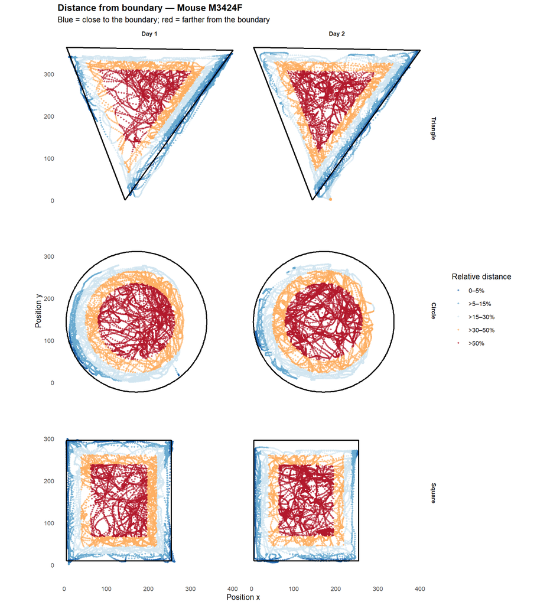

Relative distance of the selected mouse from the nearest arena boundary.

# Neuronal activity and boundary distance across mice

The following figure relates the mean proportion of active neurons to relative distance from the nearest arena boundary.

Grey curves represent individual mice. The blue curve is the mean across mice within each distance interval, and the shaded region represents one standard error around the mean. A relative distance of zero indicates the arena boundary, while a value of one indicates the most central observed positions.

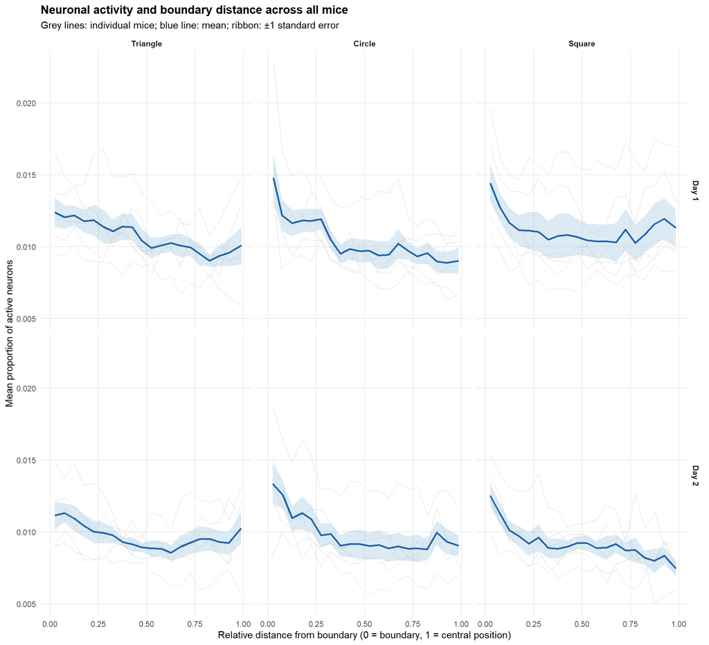

Mean neuronal activity as a function of relative boundary distance across all mice.

# Position-related neuronal activity for all mice

Each row corresponds to one mouse, and the columns distinguish arena shape and experimental day. The mice are shown separately and are not pooled within panels.

Point colour represents the proportion of simultaneously active neurons. Point size also increases with the number of active neurons to make high-activity events more visible.

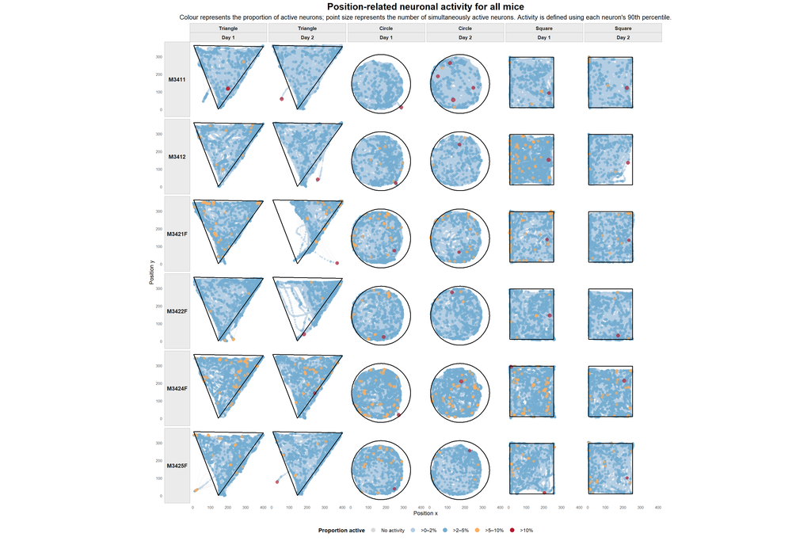

Position-related neuronal activity shown separately for every mouse, arena shape, and day.

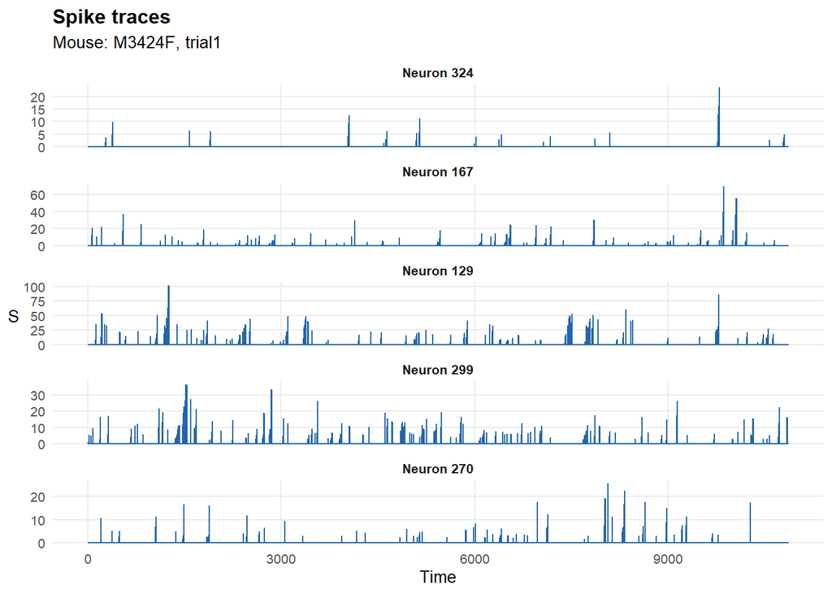